# **Panorama da inflação**

Os principais índices de inflação do Brasil, apontam em novembro de 2002 um avanço da inflação de em média **3.87%**. Com esse resultado, no ano a inflação acumula uma variação média positiva de **14.09%**, e em 12 meses uma variação média acumulada de **14.84%**.

[output not shown]

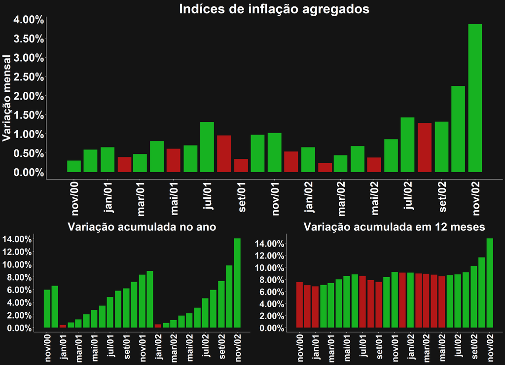

Índices selecionados para a média: IPCA, INPC e IGP-M.

# IPCA

O Indíce de Preços ao Consumidor Amplo (IPCA) variou 3.02% em novembro, valor superior ao mesmo período do ano anterior quando apresentou uma taxa de 0.71%. Com esse resultado o indíce acumula no ano uma variação positiva de 10.22%, e em 12 meses uma variação positiva de 10.93%.

|  | 11/2001 | 10/2002 | 11/2002 |
| --- | --- | --- | --- |
| Variação mensal | 0.71% | 1.31% | 3.02% |
| Variação acumulada no ano | 6.98% | 6.98% | 10.22% |
| Variação acumulada em 12 meses | 7.61% | 8.45% | 10.93% |

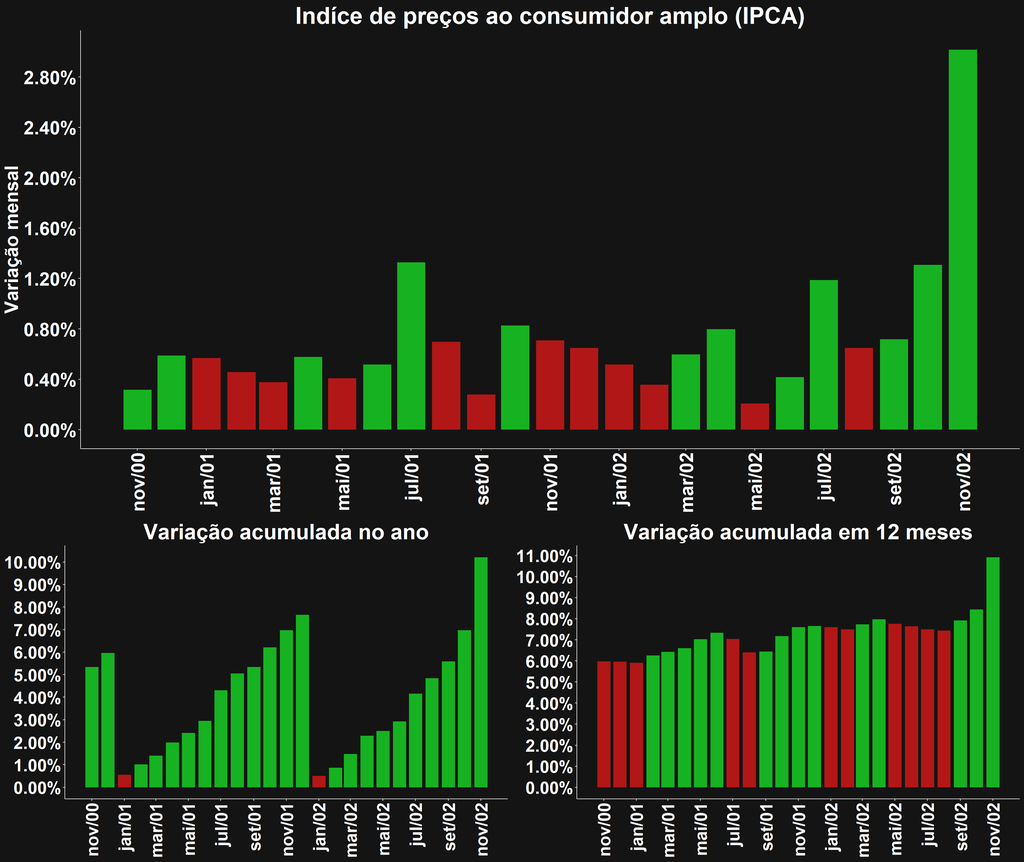

|  | Variação mensal | Variação acumulada no ano | Peso mensal |
| --- | --- | --- | --- |
| Alimentação e bebidas | 5.85% | 14.97% | 22.74% |
| Habitação | 2.02% | 11.41% | 16.38% |
| Artigos de residência | 2.88% | 10.63% | 5.74% |
| Vestuário | 0.97% | 7.81% | 5.36% |
| Transportes | 4.68% | 8.52% | 21.4% |
| Saúde e cuidados pessoais | 0.88% | 7.25% | 10.56% |
| Despesas pessoais | 0.41% | 6.04% | 9.37% |
| Educação | 0.24% | 8.14% | 4.82% |
| Comunicação | 0.03% | 11.24% | 3.62% |

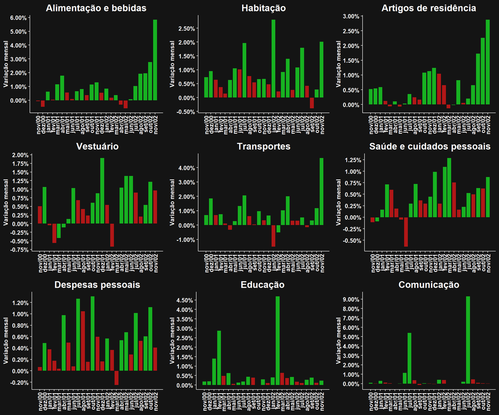

A nível de sub-itens os que mais influenciaram positivamente no resultado em relação ao seu peso foram Gasolina (10.53%%) e Etanol (26.35%%), e negativamente Pintura de veículo (-2.61%%) e Seguro voluntário de veículo (-1.27%%).

|  | Variação mensal | Variação acumulada no ano | Peso mensal |
| --- | --- | --- | --- |
| Açúcar refinado | 49.6% | 53.34% | 0.27% |
| Etanol | 26.35% | 27.72% | 0.95% |
| Gás de botijão | 12.43% | 38.92% | 1.54% |
| Gasolina | 10.53% | 10.68% | 4.11% |

|  | Variação mensal | Variação acumulada no ano | Peso mensal |
| --- | --- | --- | --- |
| Clube | -1.03% | 4.73% | 0.26% |
| Seguro voluntário de veículo | -1.27% | 10.44% | 0.33% |
| Pintura de veículo | -2.61% | -0.45% | 0.16% |
| Alho | -5.69% | 6.49% | 0.07% |

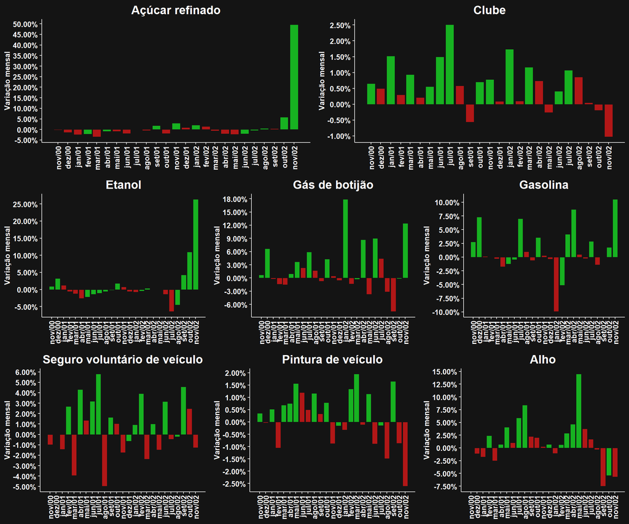

# INPC

O Indíce Nacional de Preços ao Consumidor (INPC) variou 3.39% em novembro, valor superior ao mesmo período do ano anterior quando apresentou uma taxa de 1.29%. Com esse resultado o indíce acumula no ano uma variação positiva de 11.72%, e em 12 meses uma variação positiva de 12.55%.

|  | 11/2001 | 10/2002 | 11/2002 |
| --- | --- | --- | --- |
| Variação mensal | 1.29% | 1.57% | 3.39% |
| Variação acumulada no ano | 8.64% | 8.06% | 11.72% |
| Variação acumulada em 12 meses | 9.24% | 10.26% | 12.55% |

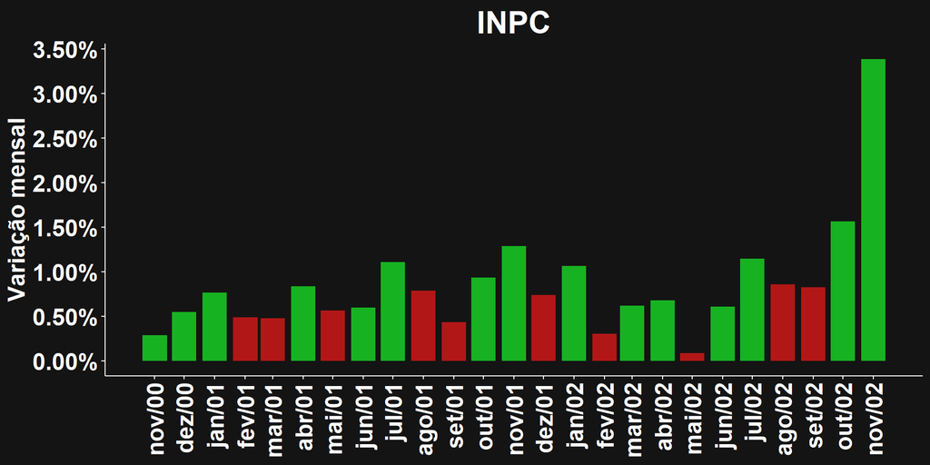

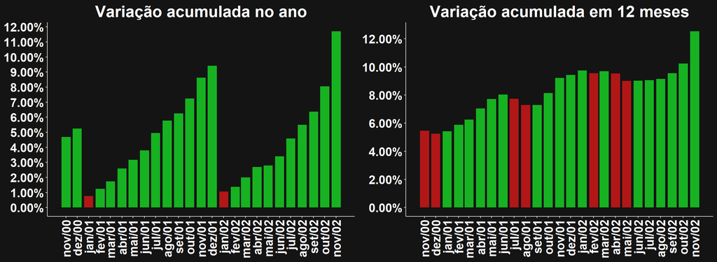

# IGP-M

O Indíce Geral de Preços de Mercado (IGP-M) variou 5.19% em novembro, valor superior ao mesmo período do ano anterior quando apresentou uma taxa de 1.1%. Com esse resultado o indíce acumula no ano uma variação positiva de 20.34%, e em 12 meses uma variação positiva de 21.05%.

|  | 11/2001 | 10/2002 | 11/2002 |
| --- | --- | --- | --- |
| Variação mensal | 1.1% | 3.87% | 5.19% |
| Variação acumulada no ano | 9.46% | 14.41% | 20.34% |
| Variação acumulada em 12 meses | 10.84% | 16.34% | 21.05% |

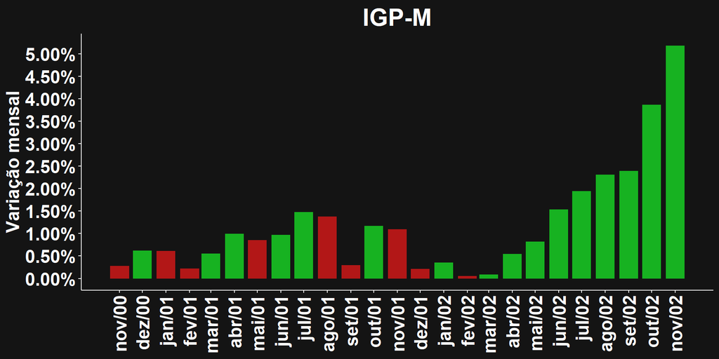

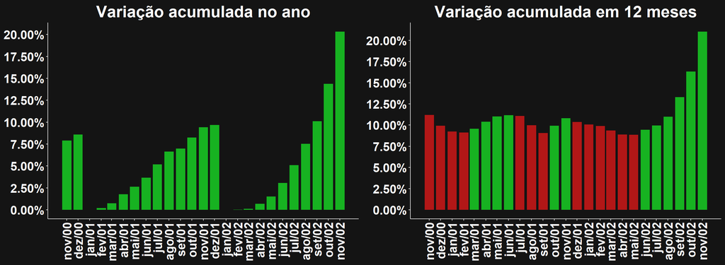

# IGP-DI

O Indíce Geral de Preços - Disponibilidade Interna (IGP-DI) variou 5.84% em novembro, valor superior ao mesmo período do ano anterior quando apresentou uma taxa de 0.76%. Com esse resultado o indíce acumula no ano uma variação positiva de 22.86%, e em 12 meses uma variação positiva de 23.31%.

|  | 11/2001 | 10/2002 | 11/2002 |
| --- | --- | --- | --- |
| Variação mensal | 0.76% | 4.21% | 5.84% |
| Variação acumulada no ano | 9.66% | 16.08% | 22.86% |
| Variação acumulada em 12 meses | 11.04% | 17.4% | 23.31% |

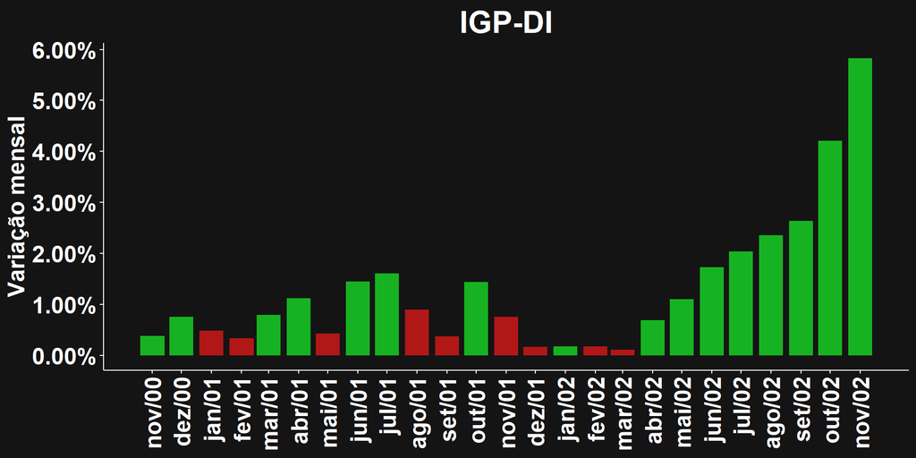

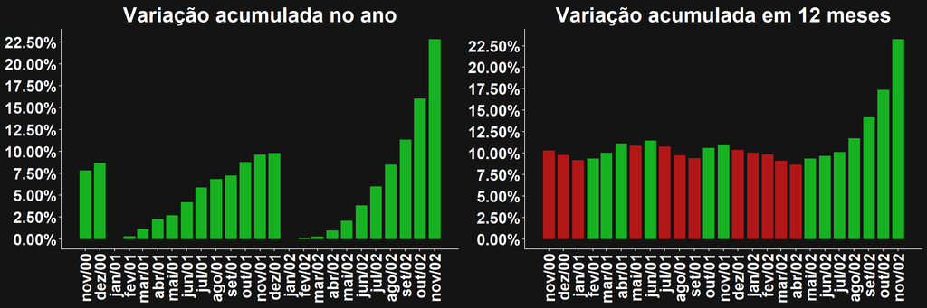

[output not shown]

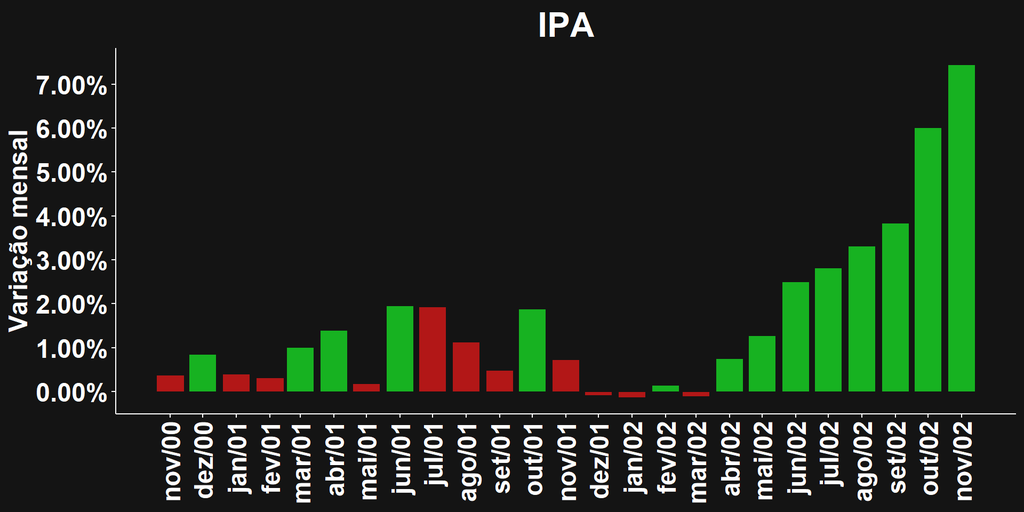

[figure not shown]

O Indíce de Preços ao Consumidor (IPC), integrante do IGP-DI com peso de 30%, apresentou variação de 3.14% em novembro, valor superior ao mesmo período do ano anterior quando apresentou uma taxa de 0.85%. Com esse resultado o indíce acumula no ano uma variação positiva de 9.17%, e em 12 meses uma variação positiva de 10.8%.

|  | 11/2001 | 10/2002 | 11/2002 |
| --- | --- | --- | --- |
| Variação mensal | 0.85% | 1.14% | 3.14% |
| Variação acumulada no ano | 6.51% | 5.85% | 9.17% |
| Variação acumulada em 12 meses | 7.86% | 8.35% | 10.8% |

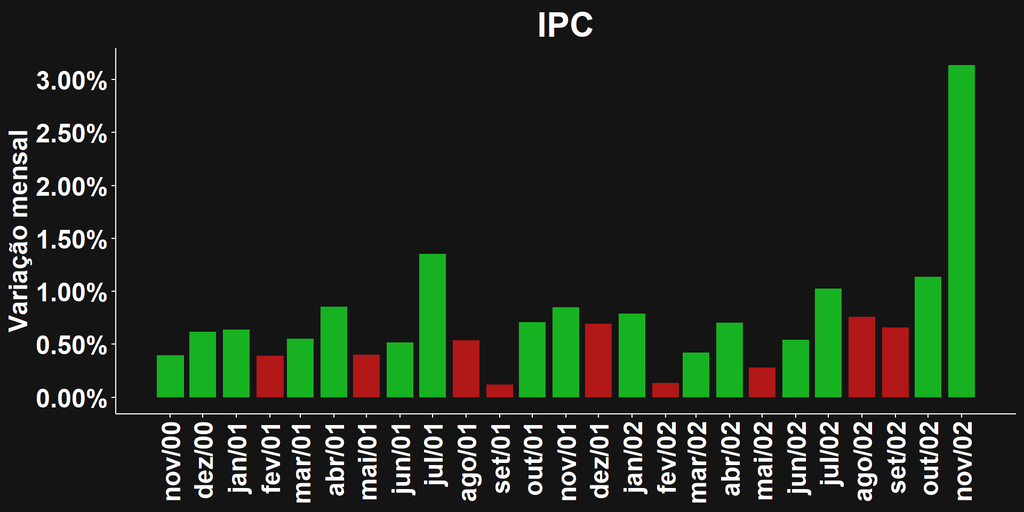

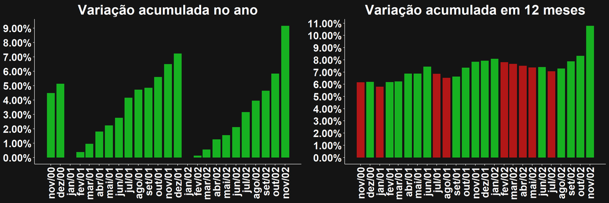

O Indíce Nacional de Custos de Construção (INCC), integrante do IGP-DI com peso de 10%, apresentou variação de 2.45% em novembro, valor superior ao mesmo período do ano anterior quando apresentou uma taxa de 0.74%. Com esse resultado o indíce acumula no ano uma variação positiva de 10.58%, e em 12 meses uma variação positiva de 11.36%.

|  | 11/2001 | 10/2002 | 11/2002 |
| --- | --- | --- | --- |
| Variação mensal | 0.74% | 1.13% | 2.45% |
| Variação acumulada no ano | 7.86% | 7.94% | 10.58% |
| Variação acumulada em 12 meses | 9.18% | 9.49% | 11.36% |

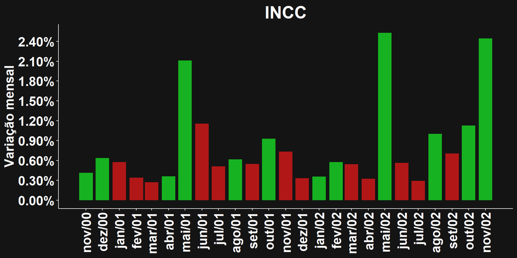

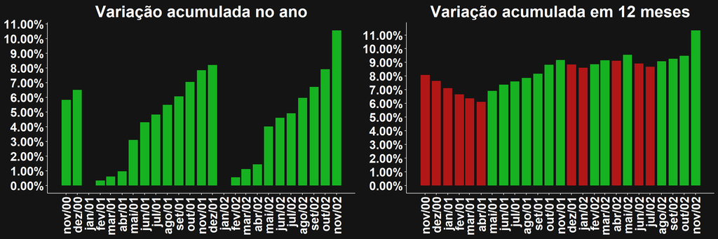

# Estatísticas

As estatísticas descritivas a seguir são feitas com base nos últimos 48 meses, e tem como objetivo possibilitar a avaliação do resultado observado em comparação aos períodos anteriores.

|  | Minimo | 1 Quartil | Mediana | Media | 3 Quartil | Maximo | Desvio Padrão |
| --- | --- | --- | --- | --- | --- | --- | --- |
| IPCA | 0.01% | 0.33% | 0.58% | 0.67% | 0.81% | 3.02% | 0.51% |
| INPC | -0.05% | 0.41% | 0.62% | 0.71% | 0.94% | 3.39% | 0.56% |
| IGP-M | -0.29% | 0.36% | 0.92% | 1.2% | 1.56% | 5.19% | 1.09% |
| IGP-DI | -0.34% | 0.39% | 1% | 1.25% | 1.65% | 5.84% | 1.19% |
| IPA | -0.82% | 0.4% | 1.31% | 1.63% | 2.35% | 7.45% | 1.75% |
| IPC | -0.01% | 0.4% | 0.61% | 0.67% | 0.86% | 3.14% | 0.54% |
| INCC | 0.05% | 0.4% | 0.58% | 0.74% | 0.92% | 2.53% | 0.51% |

Levando em consideração o desvio padrão de cada indíce, proporcionalmente os que mais se afastaram da média foram o INPC, o IPCA e o IPC.

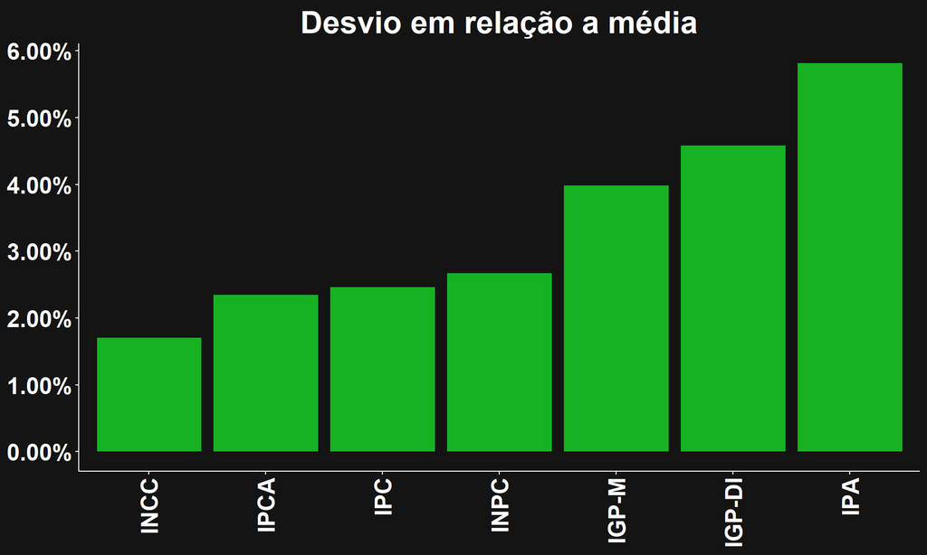

**João Victor Gomes**  
**jvg.santana@gmail.com**  
**[linkedin.com/in/jvictorgomes](https://www.linkedin.com/in/jvictorgomes/)**